# 2024 Eletion Analysis: Reporting on VP Kamala Harris and President Donald Trump

## Opening

> A review of the news organizations reporting on Former Vice President Kamala Harris and President Donald Trump during the 2024 campaigns uncovers answers to the following questions:
> - Did news outlets focus reporting on President Donald Trump and Former VP Kamala Harris equally?
> - What were the top sources for Former VP Harris and President Trump?
> - How did the rate of reporting for Former VP Harris and President Trump change nearing election day?
> - What topics did news organizations connect most to Former VP Harris and President Trump?

> The dataset reveals that President Trump received more coverage than Harris. President Trump’s top five outlets were The New York Times, CNN, The Washington Post, The Hill and NBC News, while Former VP Harris were The New York Times, Newsweek, The Hill, NBC News and CNN. Coverage for President Trump spiked in early October and November, and Former VP Harris experienced a spike in coverage in mid-to-late September.

> News outlets repeatedly mentioned the economy, abortion rights, guns, women, the Supreme Court, and student loans, identifying these as the dominant topics for Former VP Harris and President Trump’s presidential campaigns.

## Method

> Data was scraped from Google RSS feeds, organized into .csv files using Python, and cleaned with Pandas. [spaCy](https://spacy.io/), a natural language processing model, processed the headlines to identify repeated topics connected to President Trump and Former VP Harris to create the word cloud.

# Analysis

### Did news outlets focus reporting on President Donald Trump and Former VP Kamala Harris equally?

> Of the 23 news organizations that at least mentioned Former VP Harris 48 times and President Trump 62 times, 19 news organizations reported on President Trump more times than they did Former VP Harris. Four organizations mentioned Former VP Harris more times than President Trump.

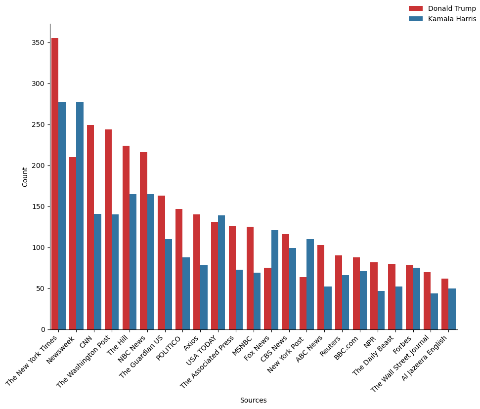

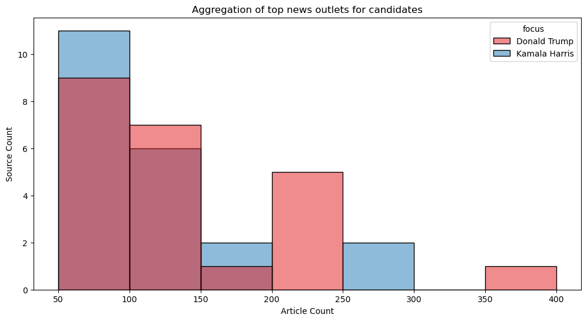

### What were the top sources for Former VP Harris and President Trump?

> The New York Times, Newsweek, The Hill, NBC News, and CNN are the five news organizations that highlighted Former VP Harris the most, with The New York Times and Newsweek mentioning Former VP Harris approximately 300 times.

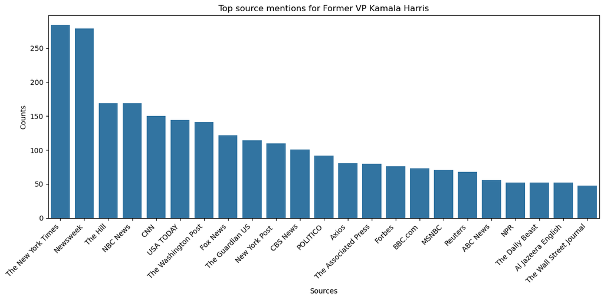

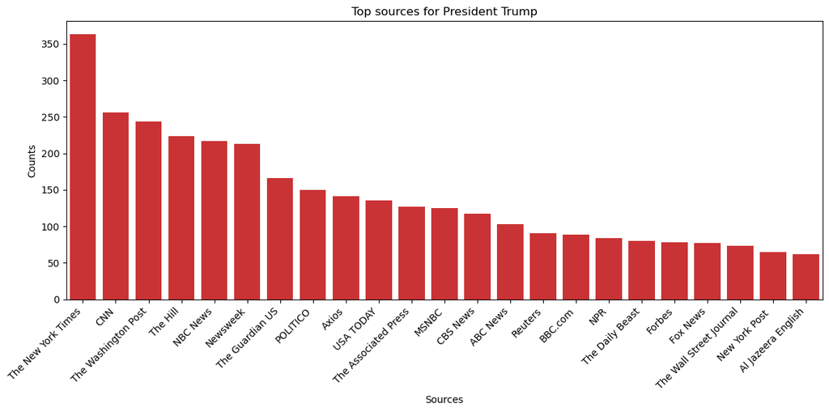

### How did the rate of reporting for Former VP Harris and President Trump change nearing election day?

> Former VP Harris dominated news coverage from early to mid-September, while she experienced a noticeable spike in coverage in late September. President Trump dominated news coverage throughout October.

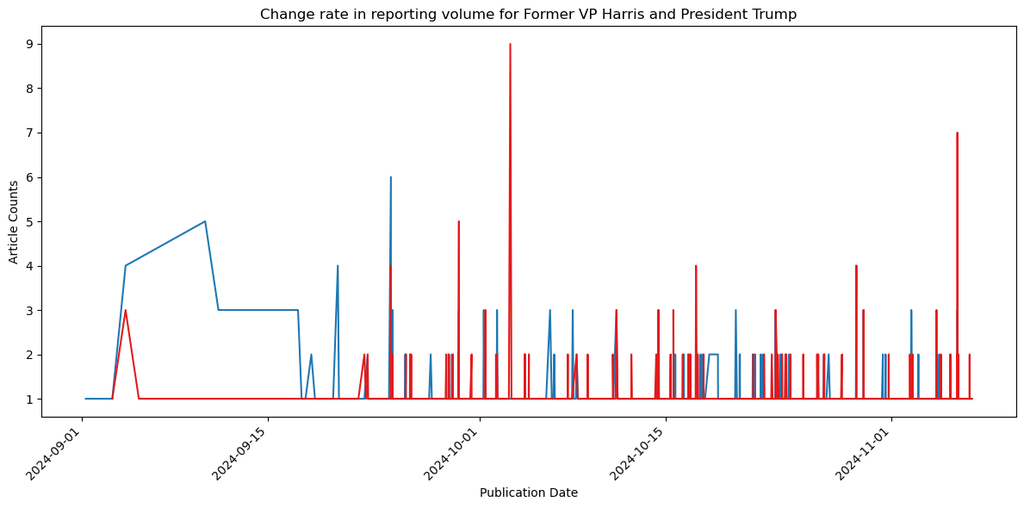

### What topics did news organizations connect most to Former VP Harris and President Trump?

> The economy, abortion rights, guns, women, the Supreme Court, and student loans were key issues. News organizations also repeatedly mentioned young voters and Gen Z, while Millennials, Boomers, and Gen X were not noticeable words identified in the word cloud.

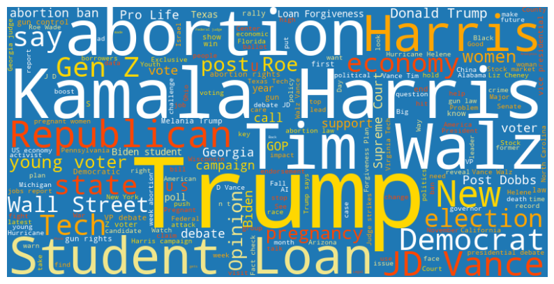

# Conclusion

> While it is visible that news organizations did not report on Former VP Harris and President Trump at a one-to-one ratio, sentiment is not an aspect of this analysis. Therefore, associations to whether coverage was positive or negative are not determined. Events surrounding spikes in coverage for either candidate could have influenced the amount of coverage either President Trump or Former VP Harris received. For example a scandal, blunder, or crime not related to the 2024 election but still involving the candidate could spike coverage.

> Advertising spend is also not an aspect of this analysis.